# Research proposal in PYTHON

## Group 22

## Xintong Cai, Sam Hu, Fanjiaxuan Zhang, Yuyao Zhou

# I) Introduction and motivation:

- For the final project, our group tries to investigate the factors that impact the sales prices of commercial real estate properties (for example: total areas, years built, and etc.) by utilizing the multiple linear regression model: $$y=\beta_0 + \beta_1 \cdot x_1 + \beta_2 \cdot x_2 + \beta_3 \cdot x_3 + ... +\beta_n \cdot x_n + \mu$$.
- In an article analyzing residential housing prices, Rao and Ge (2015) observe that, per-capita income, sales area of resident, and quantity of urban population are the main influential factors for the residential housing prices.
- Commerbcial real estate properties are similar to residential housing properties in certain aspects, yet not exactly the same. Gyourko (2009) records that the simple correlation between appreciation rates on owner occupied housing and commercial real estates is about 40%, which suggests that they are not affected by the same factors.
- Thus, it would be interesting to see how commerbcial real estate properties' sales prieces can be influenced by different factors. In this project, by conducting a multiple linear regression on sales prices, we might be able to discover important explanatory variables that affects commerbcial real estate properties' different from those affecting residential housing.
- In the follwoing section, we will commence by presenting simple descriptive statistics as well as visualizations of the data we use.

# II) Data: an overview

The data set we are using includes 9000 U.S. based commercial real estate listings for sale in 2017, organized by address, price, and other property details.

We will select the variables of interest (`'Address','City','Owner Name','Mailing Address','Price','Number of Units', 'Total area', 'Number Of Stories', 'Lot Size', 'Type', 'Year Built'`) and then perform further data cleaning to prepare the data for analysis.

Due to the large amount of nulls in the variables such as `Number of Units`, `Lot Size`, and `Year Built`, we only provide the descriptive statistics and visualizations for `Address`, `Price`, and `Total area`, for which we feel certain to include in our model.

```python
# Initialization
!pip install gmaps
!pip install geopandas
!pip install geopy
```

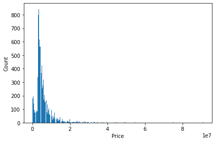

```python
import pandas as pd
import numpy as np
import matplotlib.pyplot as plt
import seaborn as sns
import gmaps
import gmaps.datasets
import geopandas
import geopy
import getpass

#Select columns
df = pd.read_csv('data_housin.csv')[
    ['Address','City','Owner Name','Mailing Address','Price','Number of Units',
    'Total area', 'Number Of Stories', 'Lot Size', 'Type', 'Year Built']
    ]
# Correct Price, total area Format
df['Price'] = df['Price'].str.replace('$','', regex = True).str.replace(',','',regex = True)
df['Total area'] = df['Total area'].str.replace(',','', regex = True).str.replace(' SF','',regex = True)

#Check if total area in other units
if len(df.loc[df['Total area'].str.match(r"(?!\d+)\w+"), ['Total area']]) == 0:
    df['Total area'] = pd.to_numeric(df['Total area'], errors = 'coerce')

# Average the price that is in the form of "LowestPrice - HighestPrice"
df.loc[df['Price'].str.match(r"(\d+) - (\d+)"), ['Price']] = df['Price'].str.replace(r"(\d+) - (\d+)", lambda x: "{}".format(
    (int(x.group(1))+int(x.group(2)))/2
    ), regex = True)
df['Price'] = pd.to_numeric(df['Price'], errors = 'coerce')

fig, ax = plt.subplots()
n, bins, patches = ax.hist(x=df['Price'], bins = 'auto', rwidth = 0.85)
ax.set_xlabel("Price")
ax.set_ylabel("Count")
fig.tight_layout()
plt.show()
```

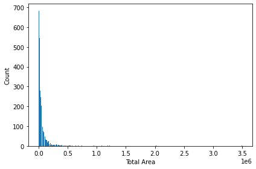

```python
fig, ax = plt.subplots()
n, bins, patches = ax.hist(x=df['Total area'], bins = 'auto', rwidth = 0.85)
ax.set_xlabel("Total Area")
ax.set_ylabel("Count")
fig.tight_layout()
plt.show()
```

```python
df.head()
```

|  | Address | City | Owner Name | Mailing Address | Price | Number of Units | Total area | Number Of Stories | Lot Size | Type | Year Built |
| --- | --- | --- | --- | --- | --- | --- | --- | --- | --- | --- | --- |
| 0 | 6060 Electron Dr., Anchorage, AK, 99518 | Anchorage, AK 99518 · | ODEX INVESTMENTS V LLC | 1001 4TH AVE STE 4500, SEATTLE, WA 98154 | 10239431.0 |  | NaN |  | 680,276 SF | Land |  |
| 1 | 1901 Airport Way, Fairbanks, AK, 99701 | Fairbanks, AK 99701 · | SEATTLE SC PLAZA 2 LLC | 1331 N CALIFORNIA BLVD STE 170, WALNUT CREEK, ... | 4050000.0 |  | 10000.0 | 1 | 3.26 AC | Office | 2006 |
| 2 | 4510 Old International Airport Rd 99502, Ancho... | Anchorage, AK 99502 · | NaN | NaN | 3500000.0 |  | 28521.0 |  | 1.09 AC | Office |  |
| 3 | 7645 W. Marigold Drive, Wasilla, AK, 99654 | Wasilla, AK 99654 · | BAKE TECHNOLOGY PARK LLC | 550 NEWPORT CENTER DR, NEWPORT BEACH, CA 92660 | 3267000.0 |  | NaN |  | 25 AC | Land |  |
| 4 | 171 Muldoon Rd, Anchorage, AK, 99504 | Anchorage, AK 99504 · | NaN | NaN | 5000000.0 |  | NaN | 1 | 81,893 SF | Retail | 1978 |

```python
df.describe()
```

|  | Price | Total area |
| --- | --- | --- |
| count | 8.899000e+03 | 4.761000e+03 |
| mean | 5.851267e+06 | 5.561844e+04 |
| std | 5.617298e+06 | 1.080743e+05 |
| min | 8.499000e+03 | 0.000000e+00 |
| 25% | 3.375000e+06 | 1.072000e+04 |
| 50% | 4.418291e+06 | 2.795900e+04 |
| 75% | 6.500000e+06 | 6.000000e+04 |
| max | 9.116890e+07 | 3.495000e+06 |

```python
APIKEY = getpass.getpass()
```

```python
# Geocoding addresses into geographic coordinates
from geopy.extra.rate_limiter import RateLimiter
locator = geopy.GoogleV3(api_key=APIKEY, timeout=20)
geocode = RateLimiter(locator.geocode, min_delay_seconds = 0.3)
df.loc[:,'location'] = df.loc[:,'Address'].apply(geocode)
df.loc[:,'point'] = df.loc[:,'location'].apply(lambda loc: tuple(loc.point) if loc else None)
df.to_csv('data.csv')
```

```python
import folium
from folium.plugins import FastMarkerCluster
#Correct file format
df = pd.read_csv("data.csv").drop(columns='Unnamed: 0')
df.loc[:,'point'] = df.loc[:,'point'].apply(lambda x: str(x)).apply(lambda x: x.replace(' ','').replace('(','').replace(')','').split(',') if x else None)

#extract geo-locations, drop na's
df[['latitude','longitude','altitude']] = pd.DataFrame(df['point'].tolist(), index=df.index)
df_map = df[pd.notna(df['location'])]

#Property Geographic Location Distribution
folium_map = folium.Map(location=[38.996990,-101.463420],
                        zoom_start=5,
                        tiles='CartoDB dark_matter')


FastMarkerCluster(data=list(zip(df_map['latitude'].values, df_map['longitude'].values))).add_to(folium_map)
folium.LayerControl().add_to(folium_map)
folium_map
```

Make this Notebook Trusted to load map: File -> Trust Notebook

[interactive chart not shown]

# III) Methodology/Empirical Model: Here you motivate and present the economic model of your regression equation or equations.

- We would like to find the correlation between sale prices of real estate properties and possible influence factors, which means analyzing one dependent variable and several independent variables. Thus, we came up with using $multiple$ $linear$ $regression$ model to investigate how strong their relationship are. And our elementary model was $price = \beta_0 + \beta_1 \cdot Address + \beta_2 \cdot GDP + \beta_3 \cdot Area + \beta_4 \cdot LotSize + \beta_5 \cdot PropertyType$ $+ \beta_6 \cdot YearBuilt + \beta_7 \cdot Floor + \mu$
- Our independent variables need to be further filtrated.
  - In a multiple linear regression model, we need to check if the independent variables are highly correlated to each other and prevent them from being in the same regression model.
  - After doing the preliminary analysis of our dataset, we found that some variables have lots of $nulls$ in their column of the dataset which may affect our final result. We may choose to analyze the variables seperately and remove the whole column from the main multiple regression model. The "messy" factors that we have noticed are $YearBuilt$ and $Floor$.
  - Varaible $Address$ is not expressed in a digital form. It is hard to find a correlation between detailed address and property price. We used address to show the distribution of our data set but may not use it in the final regression model.
- Thus, we may eliminate several terms from the initial model to set up our main regression model, which may become $price = \beta_0 + \beta_1 \cdot GDP$ $+ \beta_2 \cdot Area + \beta_3 \cdot LotSize + \beta_4 \cdot PropertyType + \mu$. And analyze the other independent variables seperately, since they might mess up the main model with too many nulls.

### References

DataWorld (2017). website: https://data.world/dmikebishop/commercial-real-estate-for-sal.

Gyourko, Joseph. Understading Commercial Real estate: Just How Different from Housing Is It? NBER Working Paper No.14708, https://www.nber.org/system/files/working_papers/w14708/w14708.pdf.

Rao, Congjun and Yangqiu Ge. Analysis of Main Influence Factors for Housing Prices. https://www.atlantis-press.com/article/25841966.pdf.

[figure not shown]

Created in Deepnote